# Assignment 5

# Exercise 3

## File output

```r
(gapminder_output <- gapminder %>%
  group_by(continent) %>%
  summarise(Min = min(pop), Median = median(pop), Max = max(pop)) %>%
  pivot_longer(cols = -continent, names_to = "Quantile", values_to = "Population")) %>%
  datatable()
```

|  | continent | Quantile | Population |
| --- | --- | --- | --- |
| 1 | Africa | Min | 60011 |
| 2 | Africa | Median | 4579311 |
| 3 | Africa | Max | 135031164 |
| 4 | Americas | Min | 662850 |
| 5 | Americas | Median | 6227510 |
| 6 | Americas | Max | 301139947 |
| 7 | Asia | Min | 120447 |
| 8 | Asia | Median | 14530830.5 |
| 9 | Asia | Max | 1318683096 |
| 10 | Europe | Min | 147962 |

[output cut: 5 more lines]

```r
gapminder_output %>%
  write_csv(here("hw5","Gapminder_changed.csv"))
str(gapminder_output)
```

```
## Classes 'tbl_df', 'tbl' and 'data.frame':    15 obs. of  3 variables:
##  $ continent : Factor w/ 5 levels "Africa","Americas",..: 1 1 1 2 2 2 3 3 3 4 ...
##  $ Quantile  : chr  "Min" "Median" "Max" "Min" ...
##  $ Population: num  6.00e+04 4.58e+06 1.35e+08 6.63e+05 6.23e+06 ...
```

## File input

```r
gapminder_input <- read_csv(here("hw5","Gapminder_changed.csv"), col_types = "ffn")
str(gapminder_input)
```

```
## Classes 'spec_tbl_df', 'tbl_df', 'tbl' and 'data.frame': 15 obs. of  3 variables:
##  $ continent : Factor w/ 5 levels "Africa","Americas",..: 1 1 1 2 2 2 3 3 3 4 ...
##  $ Quantile  : Factor w/ 3 levels "Min","Median",..: 1 2 3 1 2 3 1 2 3 1 ...
##  $ Population: num  6.00e+04 4.58e+06 1.35e+08 6.63e+05 6.23e+06 ...
##  - attr(*, "spec")=
##   .. cols(
##   ..   continent = col_factor(levels = NULL, ordered = FALSE, include_na = FALSE),
##   ..   Quantile = col_factor(levels = NULL, ordered = FALSE, include_na = FALSE),
##   ..   Population = col_number()
##   .. )
```

The class of columns `continent` and `quantile` were input as factor defined in the option `col_types = "ffn"`; otherwise they will be both input as characters.

```r
gapminder_input$Quantile %>% levels
```

```
## [1] "Min"    "Median" "Max"
```

```r
gapminder_input %>%
  mutate(Quantile = fct_rev(Quantile)) %>% ## reorder the levels of Quantile
  arrange(Quantile) %>%
  datatable()
```

|  | continent | Quantile | Population |
| --- | --- | --- | --- |
| 1 | Africa | Max | 135031164 |
| 2 | Americas | Max | 301139947 |
| 3 | Asia | Max | 1318683096 |
| 4 | Europe | Max | 82400996 |
| 5 | Oceania | Max | 20434176 |
| 6 | Africa | Median | 4579311 |
| 7 | Americas | Median | 6227510 |
| 8 | Asia | Median | 14530830.5 |
| 9 | Europe | Median | 8551125 |
| 10 | Oceania | Median | 6403491.5 |

[output cut: 5 more lines]

The order of levels becomes “max, median, min”.

# Exercise 4

#### Task: Create a side-by-side plot and juxtapose your first attempt (show the original figure as-is) with a revised attempt after some time spent working on it and implementing principles of effective plotting principles. Comment and reflect on the differences.

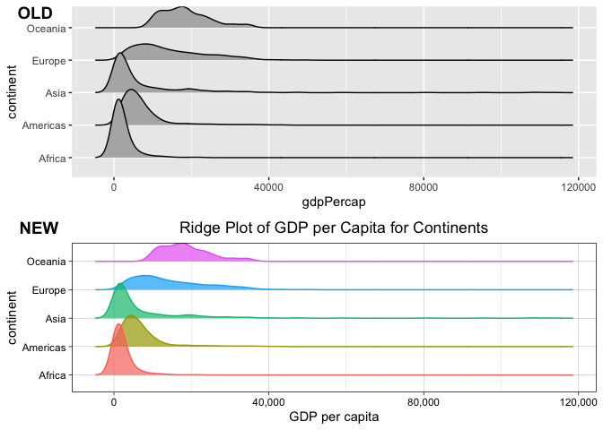

```r
p1 <- gapminder %>%
  ggplot(aes(gdpPercap, continent)) +
  ggridges::geom_density_ridges()

p2 <- gapminder %>%
  ggplot(aes(gdpPercap, continent)) +
  ggridges::geom_density_ridges(aes(fill = continent, colour = continent),alpha = 0.7) +
  scale_x_continuous(labels = scales::comma_format()) +
  theme_linedraw() +
  theme(legend.position = "none") +
  ggtitle("Ridge Plot of GDP per Capita for Continents") +
  xlab("GDP per capita")+
  theme(plot.title = element_text(hjust = 0.5))

(plot_grid(p1, p2, ncol = 1,
          labels = c("OLD", "NEW")) -> p)
```

- Colors of the ridges were added to the plot.
- X-axis is adjusted to follow the comma format.
- The label for x-axis and title for the whole plot were added.
- Theme of the plot is revised.

# Exerceise 5

```r
ggsave(here("hw5","Plot1.png"), plot = p1)
ggsave(here("hw5","Plot2.png"), plot = p2)
ggsave(here("hw5","Plot.png"), plot = p)
```

Here we show the three plots just got saved to local path in order:

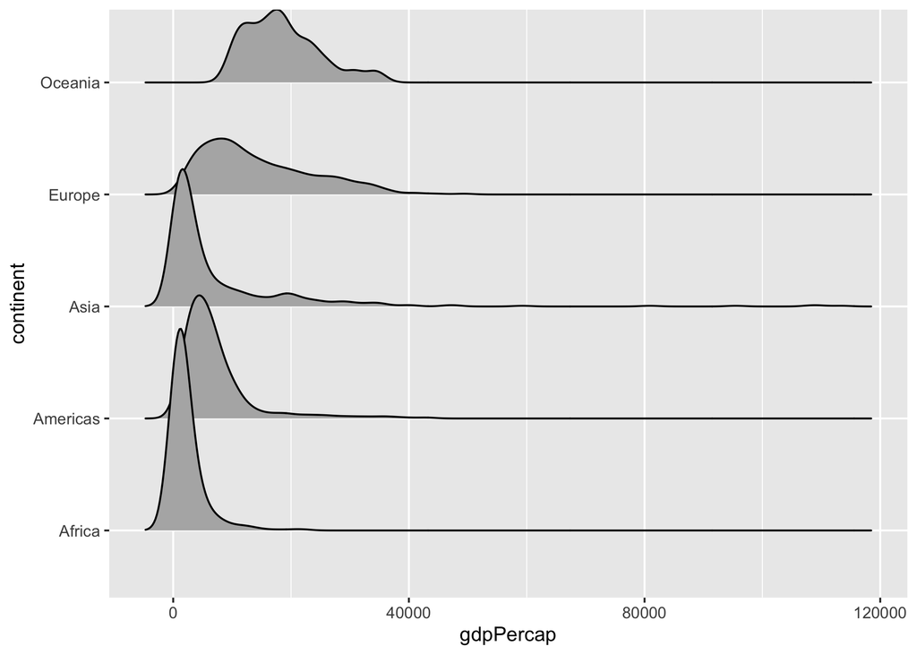

P1. the original plot

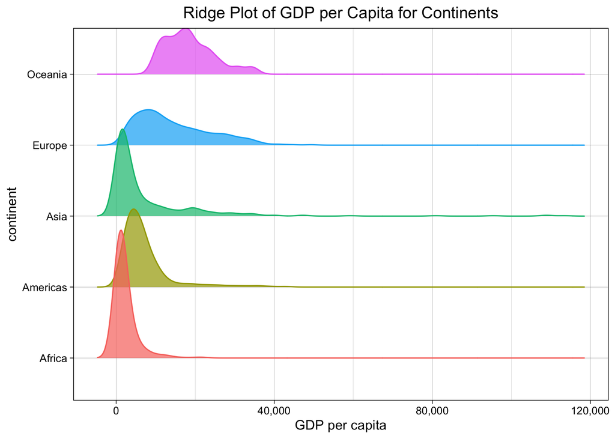

P2. the revised plot

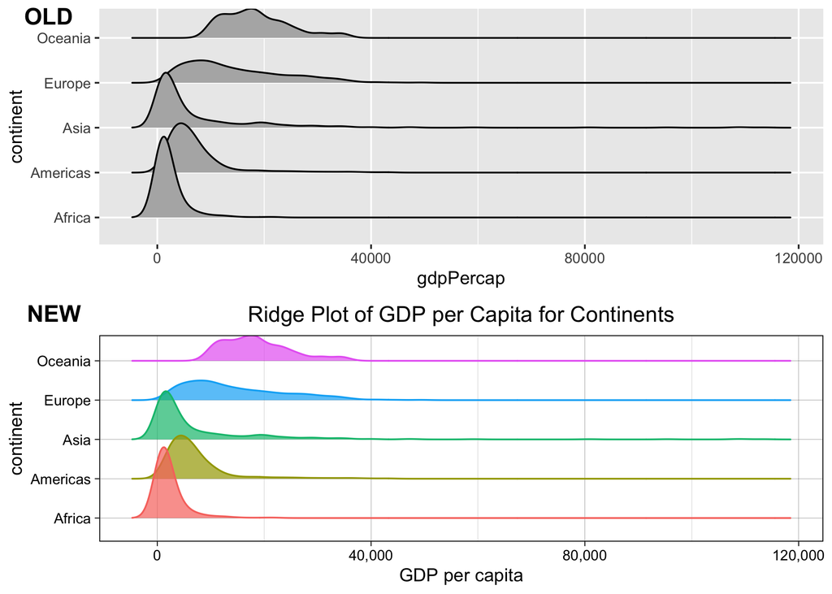

P3. comparison of the old and the new plots

From these figures, we can say `ggsave` works perfectly.